# ISLR Chapter 10

Alex Bayers

11/25/2018

# Exercise 2

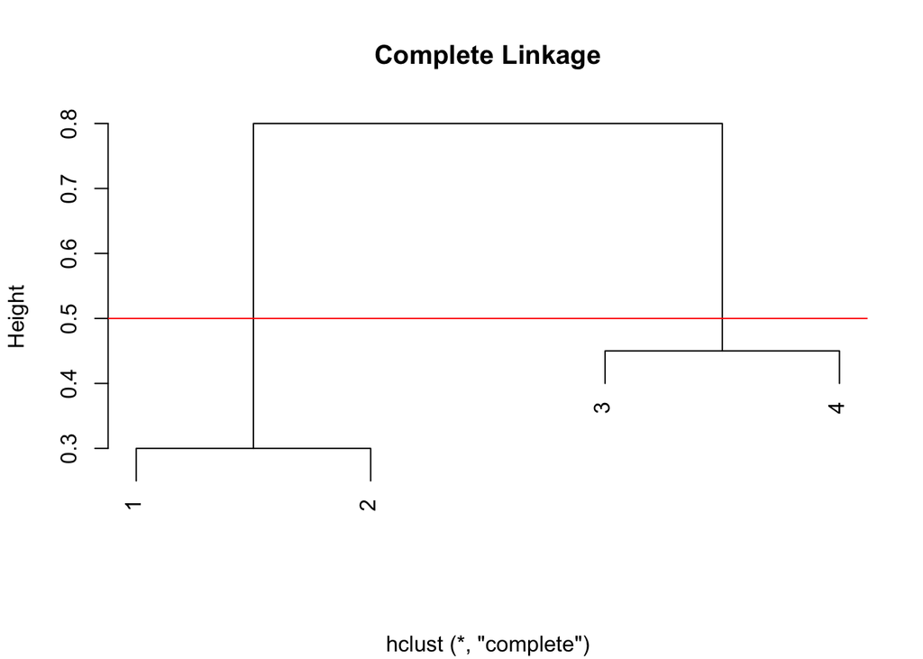

```r
data = c(0, .3, .4, .7, 0.3, 0, 0.5, 0.8, 0.4, 0.5, 0, 0.45, 0.7, 0.8, 0.45, 0)
data <- as.dist(matrix(data, nrow = 4, ncol = 4), diag = TRUE)
complete.clust <- hclust(data)
single.clust <- hclust(data, method = "single")
complete.trees <- cutree(complete.clust, k = 2)
plot(complete.clust, main = "Complete Linkage", xlab = "")
abline(a=.5, b = 0, col = "red")
```

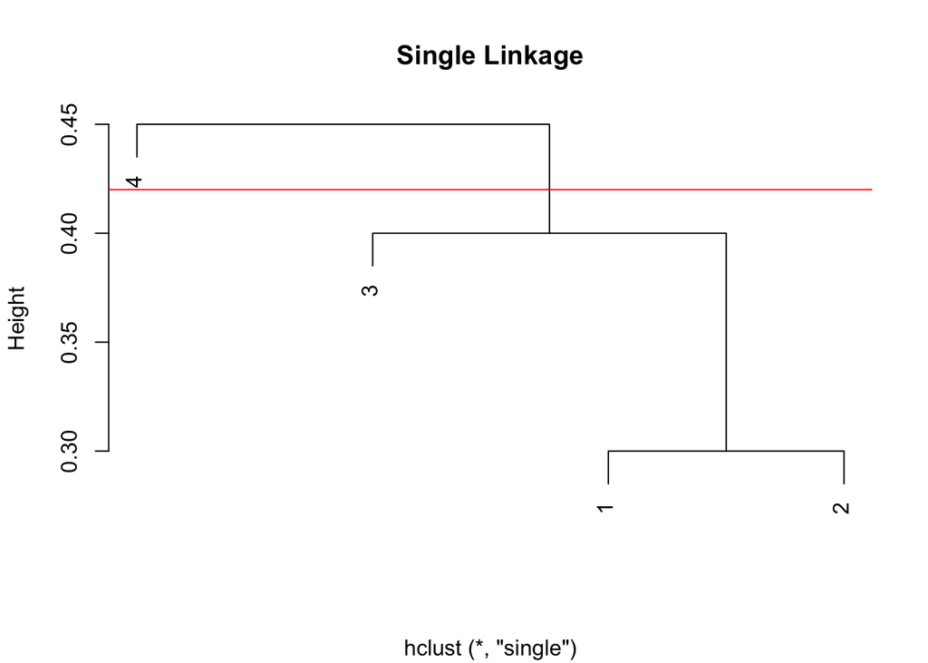

```r
plot(single.clust, main = "Single Linkage", xlab = "")
abline(a=.42, b = 0, col = "red")
```

Complete linkage results in clusters of 1 & 2, and 3 & 4. Single linkage results in 1, 2, 3, and a separate cluster at 4.

### Exercise 3

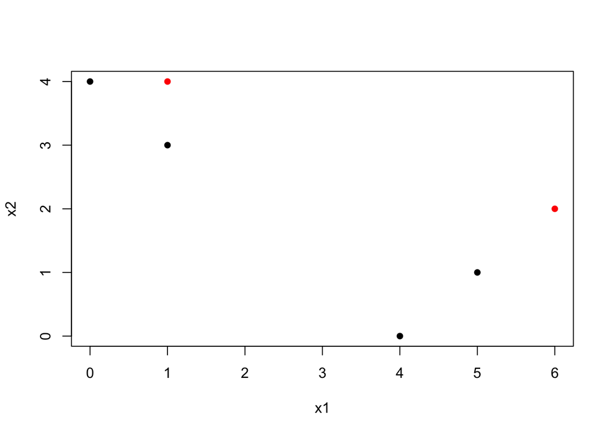

```r
library(ISLR)
set.seed(4)
x1 <- c(1, 1, 0, 5, 6, 4)
x2 <- c(4, 3, 4, 1, 2, 0)
ylabel <- sample(c(1, 2), 6, TRUE)
my.frame <- data.frame(x1, x2, ylabel)
oldylabel  <- rep(0, 6)
plot(x = x1, y = x2, col = ylabel, pch = 16)
```

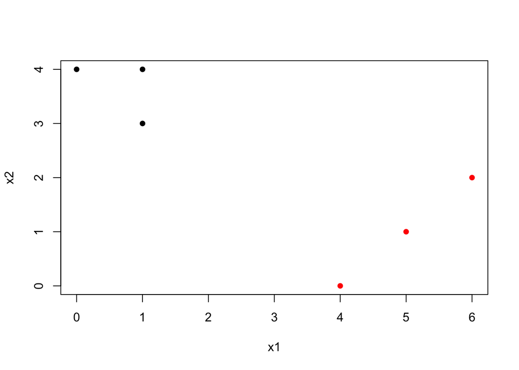

```r
while (any(oldylabel != my.frame$ylabel)){
  y1.mean <- colMeans(subset(my.frame, ylabel == 1))
  y2.mean <- colMeans(subset(my.frame, ylabel == 2))

  y1.demeaned <- sweep(my.frame, 2, y1.mean)
  y2.demeaned <- sweep(my.frame, 2, y2.mean)

  x1.distance <- (y1.demeaned$x1^2 + y1.demeaned$x2^2)^.5
  x2.distance <- (y2.demeaned$x1^2 + y2.demeaned$x2^2)^.5
  oldylabel <- my.frame$ylabel
  my.frame$ylabel <- ifelse(x1.distance < x2.distance, 1, 2)
  newtest = 1
}
plot(x = x1, y = x2, col = my.frame$ylabel, pch = 16)
```

```r
print(my.frame)
```

```
##   x1 x2 ylabel
## 1  1  4      1
## 2  1  3      1
## 3  0  4      1
## 4  5  1      2
## 5  6  2      2
## 6  4  0      2
```

### Exercise 4

##### A

The fusion will occur higher up in the complete linkage rather than the single linkage, because they will be fused on the maximal distance rather than the minimum distance.

##### B

They will fuse at the same height, because there are no other linkages when they’re fusing.

# Exercise 5.

Left Hand Chart - We would group yellow, purple, black, and light red together as one group. Center Chart - We would group yellow, blue, light red, and purple together. Right Chart - We would group yellow, blue, light red, and purple together.

### Exercise 7

```r
library(ISLR)
scaled.arrests <- scale(t(USArrests))
arrests.dist <- dist(t(scaled.arrests), diag = TRUE)
as.matrix(arrests.dist^2) / (1-cor(scaled.arrests))
```

```
##                Alabama Alaska Arizona Arkansas California Colorado
## Alabama            NaN      6       6        6          6        6
## Alaska               6    NaN       6        6          6        6
## Arizona              6      6     NaN        6          6        6
## Arkansas             6      6       6      NaN          6        6
## California           6      6       6        6        NaN        6
## Colorado             6      6       6        6          6      NaN
## Connecticut          6      6       6        6          6        6
## Delaware             6      6       6        6          6        6
## Florida              6      6       6        6          6        6
## Georgia              6      6       6        6          6        6
## Hawaii               6      6       6        6          6        6
## Idaho                6      6       6        6          6        6
## Illinois             6      6       6        6          6        6
## Indiana              6      6       6        6          6        6
## Iowa                 6      6       6        6          6        6
## Kansas               6      6       6        6          6        6
## Kentucky             6      6       6        6          6        6
## Louisiana            6      6       6        6          6        6
## Maine                6      6       6        6          6        6
## Maryland             6      6       6        6          6        6
## Massachusetts        6      6       6        6          6        6
## Michigan             6      6       6        6          6        6
## Minnesota            6      6       6        6          6        6
## Mississippi          6      6       6        6          6        6
## Missouri             6      6       6        6          6        6
## Montana              6      6       6        6          6        6
## Nebraska             6      6       6        6          6        6
## Nevada               6      6       6        6          6        6
## New Hampshire        6      6       6        6          6        6
## New Jersey           6      6       6        6          6        6
## New Mexico           6      6       6        6          6        6
## New York             6      6       6        6          6        6
## North Carolina       6      6       6        6          6        6
## North Dakota         6      6       6        6          6        6
## Ohio                 6      6       6        6          6        6
## Oklahoma             6      6       6        6          6        6
## Oregon               6      6       6        6          6        6
## Pennsylvania         6      6       6        6          6        6
## Rhode Island         6      6       6        6          6        6
```

[output cut: 404 more lines]

```
## Oklahoma                   6         6       6
## Oregon                     6         6       6
## Pennsylvania               6         6       6
## Rhode Island               6         6       6
## South Carolina             6         6       6
## South Dakota               6         6       6
## Tennessee                  6         6       6
## Texas                      6         6       6
## Utah                       6         6       6
## Vermont                    6         6       6
## Virginia                   6         6       6
## Washington                 6         6       6
## West Virginia            NaN         6       6
## Wisconsin                  6       NaN       6
## Wyoming                    6         6     NaN
```

The proportion is 6.

### Exercise 8

```r
scaled.arrests <- scale(USArrests)
#A
pc.arrests <- prcomp(scaled.arrests)
pc.var <- pc.arrests$sdev^2
pve <- pc.var/sum(pc.var)
pve
```

```
## [1] 0.62006039 0.24744129 0.08914080 0.04335752
```

```r
#B?
apply((scaled.arrests %*% pc.arrests$rotation)^2, 2, sum)/196
```

```
##        PC1        PC2        PC3        PC4
## 0.62006039 0.24744129 0.08914080 0.04335752
```

### Exercise 9

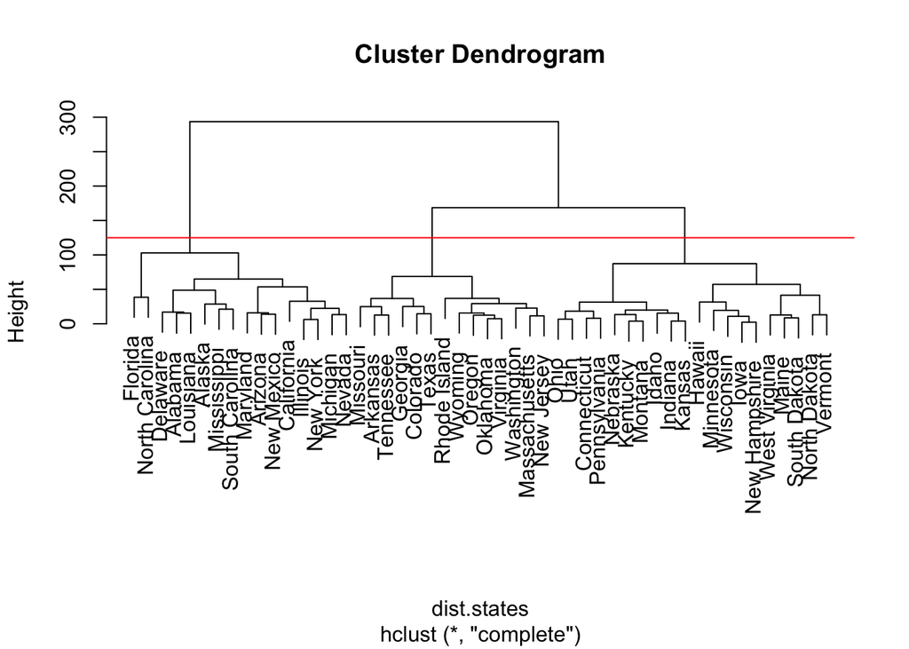

```r
#A
dist.states <- dist(USArrests)
states.clust <- hclust(dist.states)
plot(states.clust)

#B
states.tree <- cutree(states.clust, k = 3)
abline(a = 125, b = 0, col = "red")
```

```r
states.tree[states.tree== 1]
```

```
##        Alabama         Alaska        Arizona     California       Delaware
##              1              1              1              1              1
##        Florida       Illinois      Louisiana       Maryland       Michigan
##              1              1              1              1              1
##    Mississippi         Nevada     New Mexico       New York North Carolina
##              1              1              1              1              1
## South Carolina
##              1
```

```r
states.tree[states.tree== 2]
```

```
##      Arkansas      Colorado       Georgia Massachusetts      Missouri
##             2             2             2             2             2
##    New Jersey      Oklahoma        Oregon  Rhode Island     Tennessee
##             2             2             2             2             2
##         Texas      Virginia    Washington       Wyoming
##             2             2             2             2
```

```r
states.tree[states.tree== 3]
```

```
##   Connecticut        Hawaii         Idaho       Indiana          Iowa
##             3             3             3             3             3
##        Kansas      Kentucky         Maine     Minnesota       Montana
##             3             3             3             3             3
##      Nebraska New Hampshire  North Dakota          Ohio  Pennsylvania
##             3             3             3             3             3
##  South Dakota          Utah       Vermont West Virginia     Wisconsin
##             3             3             3             3             3
```

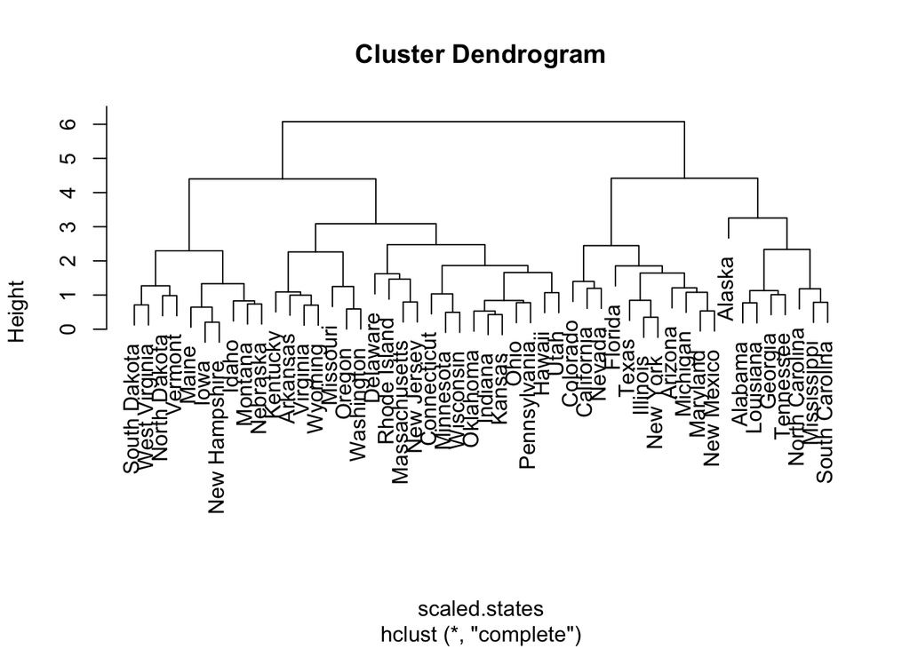

```r
#C
scaled.arrests <- scale(USArrests)
scaled.states <- dist(scaled.arrests)
scaled.clust <- hclust(scaled.states)
plot(scaled.clust)
```

```r
scaled.tree <- cutree(scaled.clust, k = 4)

scaled.tree[scaled.tree== 1]
```

```
##        Alabama         Alaska        Georgia      Louisiana    Mississippi
##              1              1              1              1              1
## North Carolina South Carolina      Tennessee
##              1              1              1
```

```r
scaled.tree[scaled.tree== 2]
```

```
##    Arizona California   Colorado    Florida   Illinois   Maryland
##          2          2          2          2          2          2
##   Michigan     Nevada New Mexico   New York      Texas
##          2          2          2          2          2
```

```r
scaled.tree[scaled.tree== 3]
```

```
##      Arkansas   Connecticut      Delaware        Hawaii       Indiana
##             3             3             3             3             3
##        Kansas      Kentucky Massachusetts     Minnesota      Missouri
##             3             3             3             3             3
##    New Jersey          Ohio      Oklahoma        Oregon  Pennsylvania
##             3             3             3             3             3
##  Rhode Island          Utah      Virginia    Washington     Wisconsin
##             3             3             3             3             3
##       Wyoming
##             3
```

```r
scaled.tree[scaled.tree== 4]
```

```
##         Idaho          Iowa         Maine       Montana      Nebraska
##             4             4             4             4             4
## New Hampshire  North Dakota  South Dakota       Vermont West Virginia
##             4             4             4             4             4
```

The scaled clusters seem much more intuitive. For example, clustering California with Alabama or Alaska doesn’t seem particulary intuitive (in the unscaled example); wheareas in the scaled example we cluster it with New York and Florida, for example.

# Exercise 10

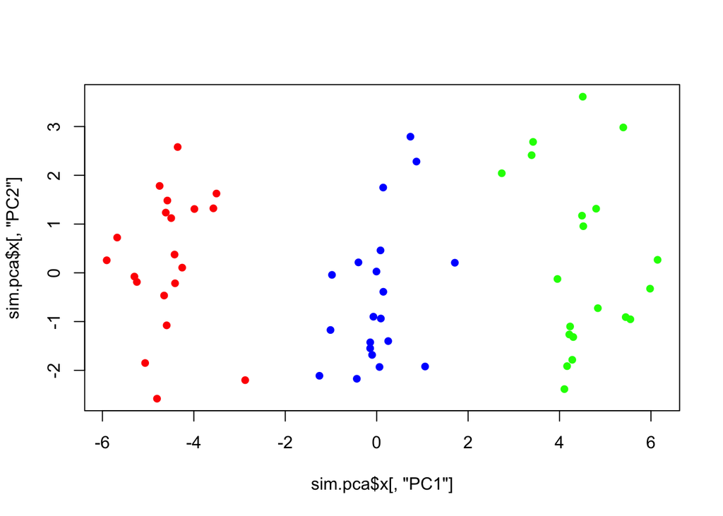

```r
#A
set.seed(5)
innov.matrix <- matrix(rnorm(3000), nrow = 60, ncol = 50)
mean.shift <- c(rep(-.75, 20), rep(0, 20), rep(.75, 20))
class.matrix <- c(rep(1, 20), rep(2, 20), rep(3, 20))
color.matrix <- c("red", "blue", "green", "yellow")
mean.matrix <- innov.matrix + mean.shift

#B
sim.pca <- prcomp(mean.matrix, scale = TRUE)
plot(x = sim.pca$x[,"PC1"], sim.pca$x[,"PC2"], col = c(rep("red", 20), rep("blue", 20), rep("green", 20)), pch = 16)
```

```r
#C
km.3=kmeans(mean.matrix,3,nstart=20)
table(km.3$cluster, class.matrix)
```

```
##    class.matrix
##      1  2  3
##   1  0  0 20
##   2  1 20  0
##   3 19  0  0
```

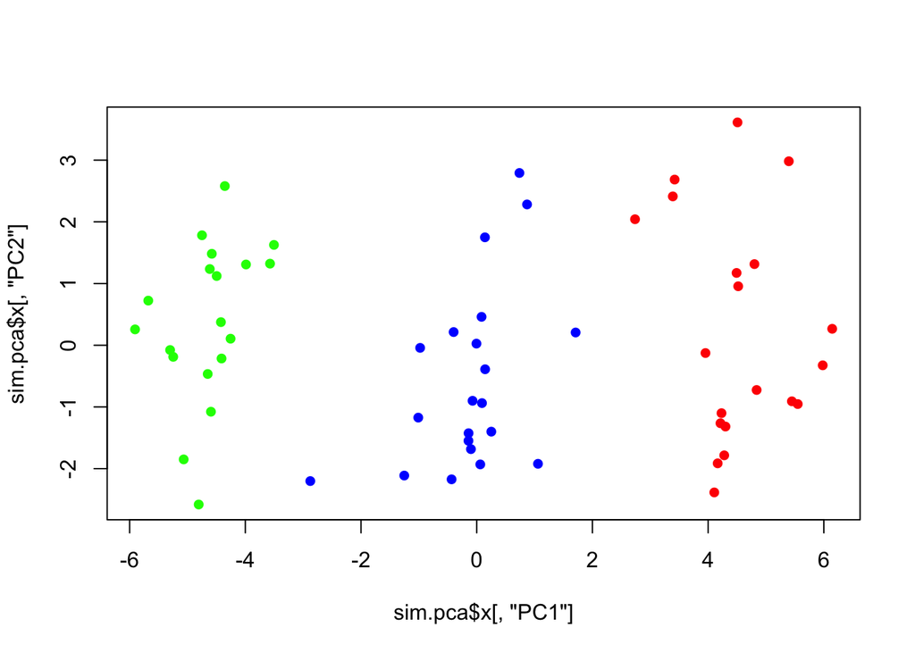

```r
plot(x = sim.pca$x[,"PC1"], sim.pca$x[,"PC2"],  pch = 16, col = color.matrix[km.3$cluster])
```

```r
#D
km.2=kmeans(mean.matrix,2,nstart=20)
table(km.2$cluster, class.matrix)
```

```
##    class.matrix
##      1  2  3
##   1 20  3  0
##   2  0 17 20
```

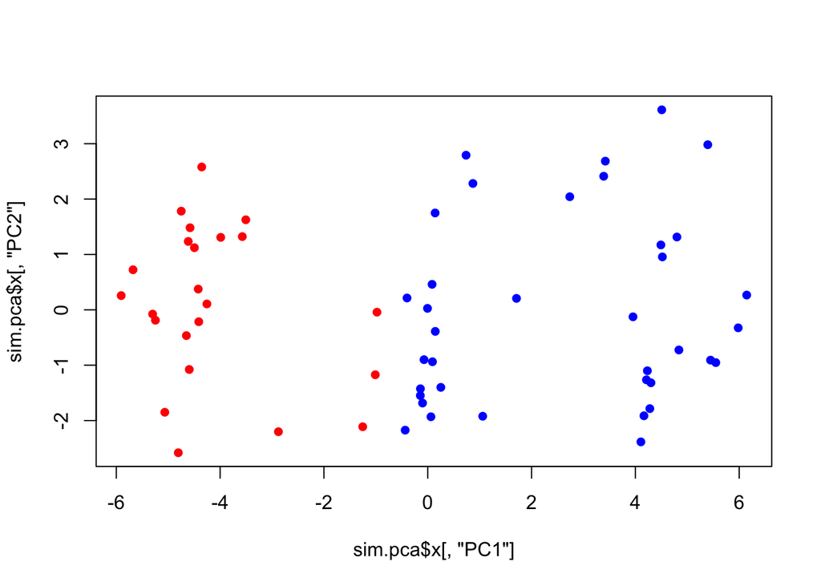

```r
plot(x = sim.pca$x[,"PC1"], sim.pca$x[,"PC2"],  pch = 16, col = color.matrix[km.2$cluster])
```

```r
#E
km.4=kmeans(mean.matrix,4,nstart=20)
table(km.4$cluster, class.matrix)
```

```
##    class.matrix
##      1  2  3
##   1  1 15  0
##   2 19  0  0
##   3  0  5  2
##   4  0  0 18
```

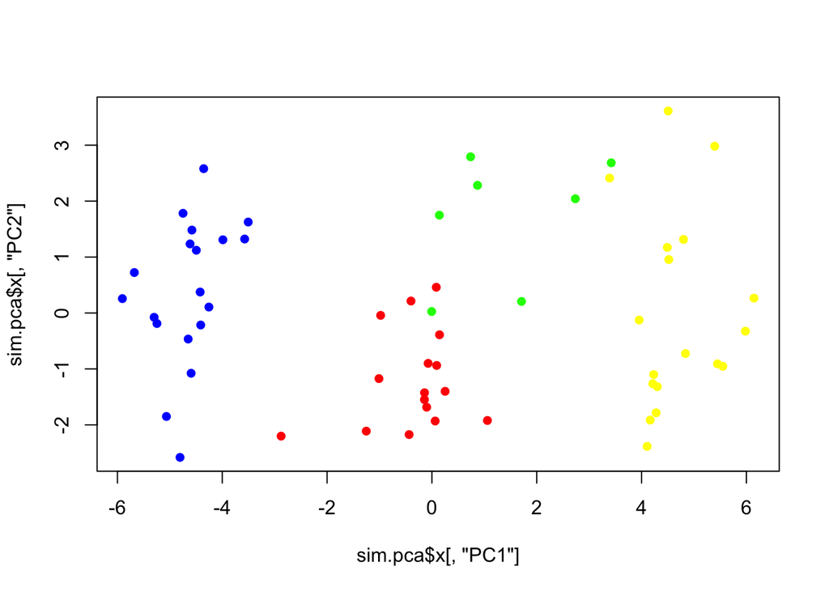

```r
plot(x = sim.pca$x[,"PC1"], sim.pca$x[,"PC2"],  pch = 16, col = color.matrix[km.4$cluster])
```